# Draft raster methodology in R

Jeff Hollister

Q Kellogg

2017-11-27

# Step 1: Load up packages required for N-Sink analysis

```r
pkgs <- c("here","archive", "httr", "raster", "sp", "rgdal", "tidyverse", "sf",
          "FedData","foreign", "fasterize", "mapview", "quickmapr", "lwgeom")
for(i in pkgs){
  if(i == "archive" & !i %in% installed.packages()){
    devtools::install_github("jimhester/archive")
  } else if(!i %in% installed.packages()){
    install.packages(i)
  }
}
x<-lapply(pkgs, library, character.only = TRUE)
```

```
## here() starts at C:/Users/JHollist/OneDrive - Environmental Protection Agency (EPA)/projects/nsink_raster
```

[output not shown]

```
## Linking to liblwgeom 2.5.0dev r16016, GEOS 3.6.1, proj.4 4.9.3
```

# Step 2: Get required data sets

## NHD Plus

Note: Need to write function to grab for specified huc

```r
# Grab data if doesn't exist locally

if(!file.exists(here("data/nhdplus_ne_fdr.7z"))){
  fdr_url <- "http://www.horizon-systems.com/NHDPlusData/NHDPlusV21/Data/NHDPlusNE/NHDPlusV21_NE_01_01a_FdrFac_01.7z"
  httr::GET(fdr_url, httr::write_disk(path = here("data/nhdplus_ne_fdr.7z")),progress())
  archive_extract(here("data/nhdplus_ne_fdr.7z"), here("data"))
}
if(!file.exists(here("data/nhdplus_ne_huc12.7z"))){
  huc12_url <- "http://www.horizon-systems.com/NHDPlusData/NHDPlusV21/Data/NHDPlusNE/NHDPlusV21_NE_01_WBDSnapshot_03.7z"
  httr::GET(huc12_url, httr::write_disk(here("data/nhdplus_ne_huc12.7z")), httr::progress())
  archive_extract(here("data/nhdplus_ne_huc12.7z"), here("data"))
}
if(!file.exists(here("data/nhdplus_ne_attributes.7z"))){
  attr_url <- "http://www.horizon-systems.com/NHDPlusData/NHDPlusV21/Data/NHDPlusNE/NHDPlusV21_NE_01_NHDPlusAttributes_08.7z"
  httr::GET(attr_url, httr::write_disk(here("data/nhdplus_ne_attributes.7z")), httr::progress())
  archive_extract(here("data/nhdplus_ne_attributes.7z"), here("data"))
}

if(!file.exists(here("data/nhdplus_ne_erom.7z"))){
  erom_url <- "http://www.horizon-systems.com/NHDPlusData/NHDPlusV21/Data/NHDPlusNE/NHDPlusV21_NE_01_EROMExtension_05.7z"
  httr::GET(erom_url, httr::write_disk(here("data/nhdplus_ne_erom.7z")), httr::progress())
  archive_extract(here("data/nhdplus_ne_erom.7z"), here("data"))
}

if(!file.exists(here("data/nhdplus_ne_snapshot.7z"))){
  fdr_url <- "http://www.horizon-systems.com/NHDPlusData/NHDPlusV21/Data/NHDPlusNE/NHDPlusV21_NE_01_NHDSnapshot_04.7z"
  httr::GET(fdr_url, httr::write_disk(path = here("data/nhdplus_ne_snapshot.7z")),progress())
  archive_extract(here("data/nhdplus_ne_snapshot.7z"), here("data"))
}
fdr_ne <- raster(here("data/NHDPlusNE/NHDPlus01/NHDPlusFdrFac01a/fdr/"))
huc12_ne <- st_read(here("data/NHDPlusNE/NHDPlus01/WBDSnapshot/WBD/WBD_Subwatershed.shp")) %>% st_transform(projection(fdr_ne))
```

```r
niantic_huc <- huc12_ne %>%
  filter(HU_12_NAME == "Niantic River") %>%
  rename_all(tolower)

## Create raster to set extent, projection, etc. for all conversions
empty_raster_30 <- fasterize::raster(niantic_huc, resolution = 30)
empty_raster_10 <- fasterize::raster(niantic_huc, resolution = 10)

niantic_fdr <- crop(fdr_ne, as(niantic_huc, "Spatial")) %>%
  projectRaster(empty_raster_30,method = "ngb")

ne_streams <- st_read(here("data/NHDPlusNE/NHDPlus01/NHDSnapshot/Hydrography/NHDFlowline.shp")) %>%
  st_transform(st_crs(niantic_huc)) %>%
  st_zm() %>%
  rename_all(tolower) %>%
  rename(stream_comid = comid,
         lake_comid = wbareacomi)
niantic_streams <- ne_streams %>%
  slice(st_contains(niantic_huc, ne_streams)[[1]]) %>%
  st_crop(st_bbox(niantic_huc))
ne_waterbodies <- st_read(here("data/NHDPlusNE/NHDPlus01/NHDSnapshot/Hydrography/NHDWaterbody.shp")) %>%
  st_transform(st_crs(niantic_huc)) %>%
  rename_all(tolower) %>%
  rename(lake_comid = comid) %>%
  filter(ftype == "LakePond")
niantic_waterbodies <- ne_waterbodies %>%
  slice(st_contains(niantic_huc, ne_waterbodies)[[1]])
```

## NLCD Percent Impervious

```r
# FedData better option
if(!file.exists(here("data/niantic_NLCD_2011_impervious.tif"))){
  niantic_imp <- get_nlcd(as(niantic_huc,"Spatial"), dataset = "impervious", label = "niantic", extraction.dir = "data")
}
niantic_imp <- projectRaster(raster(here("data/niantic_NLCD_2011_impervious.tif")), empty_raster_10)
# Note on projectRaster - used to force raster extents to be the same...
```

## SSURGO

```r
# This conditional is fragile!
if(!file.exists(here("data/ssurgo/"))){
niantic_ssurgo <- get_ssurgo(as(niantic_huc, "Spatial"), "niantic", "data/ssurgo", "data/ssurgo")
}
```

# Step 3: Summarize land, stream, and lake removal

## Land removal from hydric

```r
# Read in ssurgo
niantic_ssurgo_sf <- st_read(here("data/ssurgo/niantic_SSURGO_Mapunits.shp")) %>%
  st_transform(projection(fdr_ne))
names(niantic_ssurgo_sf) <- str_to_lower(names(niantic_ssurgo_sf))
niantic_ssurgo_tbl <- read_csv(here("data/ssurgo/niantic_SSURGO_component.csv"))%>%
  mutate(mukey = as(mukey, "character")) %>%
  select(mukey, cokey, hydricrating, comppct.r) %>%
  filter(hydricrating == "Yes") %>%
  group_by(mukey, hydricrating) %>%
  summarize(hydric_pct = sum(comppct.r))
# Convert ssurgo to hydric removal
niantic_hydric <- niantic_ssurgo_sf %>%
  mutate(mukey = as(mukey, "character")) %>%
  full_join(niantic_ssurgo_tbl, by = "mukey") %>%
  mutate(n_removal = 0.8*(hydric_pct/100)) %>%
  mutate(n_removal = case_when(n_removal == 0 ~ NA_real_,
                               TRUE ~ n_removal))
niantic_hydric_removal <- fasterize::fasterize(niantic_hydric,
                                               empty_raster_10,
                                               "n_removal",
                                               background = 0,
                                               fun = "max")

# Pull in impervious to mask out hydric
niantic_imp_na <- niantic_imp
niantic_imp_na[niantic_imp_na > 0] <- NA
niantic_imp_na[!is.na(niantic_imp_na)] <- 1
niantic_hydric_removal <- raster::mask(niantic_hydric_removal,niantic_imp_na)
```

# Stream removal

```r
# Read in external data tables
q_dat <- read.dbf(here("data/NHDPlusNE/NHDPlus01/EROMExtension/EROM_MA0001.DBF")) %>%
  select(stream_comid = ComID,q_cfs = Q0001E) %>%
  mutate(q_cms = q_cfs * 0.028316846592) %>%
  mutate(mean_reach_depth = 0.2612 * (q_cms ^ 0.3966)) %>%
  mutate_if(is.factor, as.character())

tot_dat <- read.dbf(here("data/NHDPlusNE/NHDPlus01/NHDPlusAttributes/PlusFlowlineVAA.dbf"))%>%
  rename_all(tolower) %>%
  rename(stream_comid = comid,totma = totma) %>%
  mutate_if(is.factor, as.character())

niantic_streams <- niantic_streams %>%
  mutate_if(is.factor, as.character()) %>%
  left_join(q_dat, by = c("stream_comid" = "stream_comid")) %>%
  left_join(tot_dat, by = c("stream_comid" = "stream_comid"))

# Calc stream removal
# streams are done at 30m and burnt in last
niantic_stream_removal <- niantic_streams %>%
  filter(ftype != "ArtificialPath") %>%
  mutate(totma = case_when(totma == -9999 ~ NA_real_,
                           TRUE ~ totma)) %>%
  mutate(n_removal = (1 - exp(-0.0513 * (mean_reach_depth^-1.319) * totma))/100) %>%
  raster::rasterize(empty_raster_30,
                    field = "n_removal",
                    fun = "max")
```

# Lake removal

```r
nhd_lakemorpho <- read.dbf(here("data/NHDPlusNE/NHDPlus01/NHDPlusAttributes/PlusWaterbodyLakeMorphology.dbf")) %>%
  rename_all(tolower) %>%
  rename(lake_comid = comid) %>%
  mutate_if(is.factor, as.character())

# Not used
nhd_lakemorpho_flowline <- read.dbf(here("data/NHDPlusNE/NHDPlus01/NHDPlusAttributes/PlusFlowlineLakeMorphology.dbf")) %>%
  rename_all(tolower) %>%
  rename(stream_comid = comid) %>%
  mutate_if(is.factor, as.character())

# Calc waterbody residence times which is sum of TOTMA per lake on Artifical
# Flow Paths
niantic_res_time <- niantic_streams %>%
  left_join(tot_dat) %>%
  filter(lake_comid > 0,
         totma != -9999) %>%
  group_by(lake_comid) %>%
  summarize(lake_residence_time_yrs = sum(totma*0.002737851)) %>%
  ungroup()
st_geometry(niantic_res_time) <- NULL

# Get artifical flow path removal table NEED TO CHECK REMOVAL CALCS
niantic_lake_removal <- niantic_waterbodies %>%
  left_join(nhd_lakemorpho) %>%
  left_join(niantic_res_time) %>%
  mutate(meandused = case_when(meandused < 0 ~ NA_real_,
                               TRUE ~ meandused)) %>%
  mutate(n_removal = (79.24 - (33.26 * log10(meandused/lake_residence_time_yrs)))/100) %>%
  mutate(n_removal = case_when(n_removal < 0 ~ 0,
                               TRUE ~ n_removal)) %>%
  fasterize::fasterize(empty_raster_10,
                       "n_removal",
                       fun = "max")
```

# Merge removal rasters

```r
#Need to burn in streams into hydric as hydric 30m rasterization erases most
#streams
#stream_val <- getValues(niantic_stream_removal)
#stream_val[stream_val>=0] <- 0
#stream_val[is.na(stream_val)] <- 1
#hydric_val <- getValues(niantic_hydric_removal)
#hydric_val <- hydric_val * stream_val
#niantic_hydric_removal <- setValues(niantic_hydric_removal, hydric_val)


niantic_n_removal <- raster::merge(niantic_lake_removal,
                                    niantic_hydric_removal)
niantic_n_removal <- mask(niantic_n_removal, niantic_huc)
niantic_n_removal[is.na(niantic_n_removal)] <- 0
niantic_n_removal_filter <- focal(niantic_n_removal, matrix(1,nrow = 3, ncol = 3), max)
# re-scale back to 30 m
niantic_n_removal <- projectRaster(niantic_n_removal_filter, empty_raster_30, method = "ngb")
#burn in streams
niantic_n_removal <- raster::merge(niantic_stream_removal,
                   niantic_n_removal)
```

# Create and merge removal type raster

```r
hydric_type_val <- getValues(niantic_hydric_removal)
hydric_type_val[hydric_type_val>0] <- 1
hydric_type_val[hydric_type_val == 0] <- NA
hydric_type <- setValues(niantic_hydric_removal, hydric_type_val)
stream_type_val <- getValues(niantic_stream_removal)
stream_type_val[!is.na(stream_type_val)] <- 2
stream_type <- setValues(niantic_stream_removal,stream_type_val)
lake_type_val <- getValues(niantic_lake_removal)
lake_type_val[!is.na(lake_type_val)] <- 3
lake_type <- setValues(niantic_lake_removal, lake_type_val)
niantic_types <- merge(lake_type,
                       hydric_type)
niantic_types <- mask(niantic_types, niantic_huc)
niantic_types[is.na(niantic_types)] <- 0
# Create mode function:
Mode <- function(x) {
  ux <- unique(x)
  ux[which.max(tabulate(match(x, ux)))]
}
niantic_types_filter <- focal(niantic_types, matrix(1,nrow = 3, ncol = 3), max) #matches the removal, but max for categories ...
# re-scale back to 30 m
niantic_types <- projectRaster(niantic_types_filter, empty_raster_30, method = "ngb")
niantic_types <- raster::merge(stream_type,niantic_types)
```

Create stack of type and removal

```r
niantic_n_removal_type_stack <- stack(niantic_n_removal, niantic_types)
```

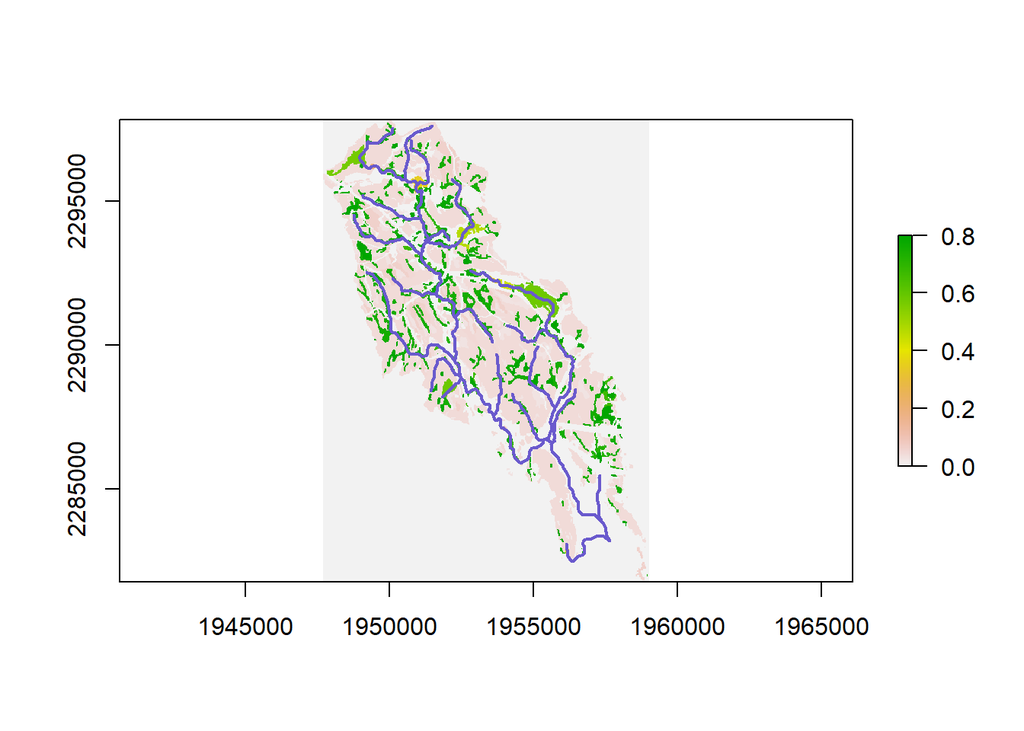

```r
# Simple plot!
#brks <- c(0,0.1,0.2,0.3,0.4,0.5,0.6,0.7,0.8)
#color <- rev(RColorBrewer::brewer.pal(9,"RdYlBu"))
plot(niantic_n_removal)
plot(niantic_streams$geometry, add = T, col = "slateblue", lwd = 2)
```

## How to calc flow path stuff

## Calculate the flow path of interest

This can all be done direclty in r with `raster::flowPath()`

Issues with flowpath not following the streams exactly.

Ideas: 1. Calc flow path

```r
#plot(niantic_huc$geometry)
#plot(niantic_streams$geometry, add = T)
#loc <- unlist(locator(1)) #can use this for interactive
loc <- c(1948121,2295822)
example_fp_niantic <- flowPath(niantic_fdr, loc)
example_fp_xy <- xyFromCell(empty_raster_30, example_fp_niantic)
fp_n_sf <- st_sfc(st_linestring(example_fp_xy), crs = st_crs(niantic_streams)) %>%
  st_sf
```

2. Get land portion of flow path

```r
# https://github.com/r-spatial/sf/issues/749
# https://gis.stackexchange.com/questions/283131/r-reinsertion-of-intersection-points-into-initial-dataset-after-sfst-interse/283269#283269

get_path_ends <- function(fp, streams){
  # remove linear intersections
  streams <- st_difference(st_combine(streams), st_combine(fp))
  splits <- st_split(fp, st_combine(streams))
  splits <- st_collection_extract(splits, "LINESTRING")
  ends <- rbind(splits[1,], splits[nrow(splits),])
  ends
}

fp_ends <- get_path_ends(fp_n_sf, niantic_streams)
```

3. Get nhd flowline portion of flow path.

```r
library(igraph)
niantic_streams_df <- niantic_streams %>%
  select(fromnode, tonode, stream_comid)
st_geometry(niantic_streams_df) <- NULL
niantic_streams_df <- mutate_all(niantic_streams_df, funs(as.character))
niantic_streams_g <- graph_from_data_frame(niantic_streams_df, directed = TRUE)

from_nd_idx <- st_is_within_distance(fp_ends[1,], niantic_streams, 0.01)[[1]]
to_nd_idx <- st_is_within_distance(fp_ends[2,], niantic_streams, 0.01)[[1]]
from_nd <- niantic_streams_df[from_nd_idx,]$fromnode
to_nd <- niantic_streams_df[to_nd_idx,]$tonode
idx <- shortest_paths(niantic_streams_g, from_nd, to_nd, output = "epath", mode = "out")$epath[[1]]
fl_comids <- igraph::edge_attr(niantic_streams_g, "stream_comid", idx)
fp_end_pt <- tail(st_cast(fp_ends[1,], "POINT"), 1)
fp_flowlines <- niantic_streams %>%
  slice(match(fl_comids, .$stream_comid)) %>%
  st_snap(fp_end_pt, 1) %>%
  st_split(st_combine(fp_end_pt)) %>%
  st_collection_extract("LINESTRING") %>%
  filter(!st_overlaps(st_snap(., fp_ends[1,], 0.1), fp_ends[1,],F))
```

6. Combine together in combo flowpath vector and extract data along that flowpath

```r
niantic_fp <- rbind(fp_ends[1,],select(fp_flowlines, geometry))
# Collapse into a single linestring
niantic_fp <- unique(st_coordinates(niantic_fp)[,-3]) %>%
  st_linestring() %>%
  st_sfc() %>%
  st_sf(crs = st_crs(niantic_streams))
```

```r
niantic_fp_r <- niantic_fp %>%
  raster::rasterize(empty_raster_30,
                    1,
                    max)
niantic_fp_removal_r <- niantic_fp_r * niantic_n_removal

niantic_fp_extract <- raster::extract(niantic_n_removal_type_stack, niantic_fp,
                                      along = TRUE)
niantic_fp_removal <- niantic_fp_extract[[1]][,1]
niantic_fp_types <- niantic_fp_extract[[1]][,2]
```

7. Vector is Corrector or raster conversion funny business… In some flowpaths that flow along edge of a feature there is a problem caused by the rasterization of that feature which results in the flowpath going in and out of the feature. A reasonable solution is to use a moving window to filter out these instances. A window of 3 pixels makes sense as the accepted MMU for a raster is a 3x3 pixel. In this case, I filter the flow path which limits our removal features to ones that are at least 90m in length. We should discuss this so that all understand and are on board.

As I am working on summarizing this, I think it may be possible to avoid this by NOT rasterizing the stream and lake. All of the info is by stream reach (artifical flow path or not). This rasterization problem is of our (mine) making. re-think how to calculate flow path removal with hybrid raster (land based) and vector (NHD Plus flowlines). In the meantime, what is below is how to pull this info out of the raster only approach.

```r
fp_removal_max_filter <- zoo::rollmax(niantic_fp_removal, 3)
fp_types_max_filter <- zoo::rollmax(niantic_fp_types, 3)
```

8. Total Reduction Calculation This returns just the total removal along a flow path.

```r
fp_last <- zoo::rollapply(fp_removal_max_filter, width = 2, partial = TRUE,
                          function(x) ifelse(x[1]==x[2],0, x[1]))
fp_last <- ifelse(is.na(fp_last),fp_removal_max_filter[length(fp_removal_max_filter)],fp_last)
fp_last_removal <- 1-fp_last
total_removal <- cumprod(c(100,fp_last_removal))
min(total_removal)
```

```
## [1] 5.551817
```

## Output

### Example output #1 - Nitrogen removal per segment (drop to integer values)

[output not shown]

```r
type_removal_df <- data_frame(type_code = fp_types_max_filter,
                              removal = fp_removal_max_filter) %>%
  mutate(segment_type = case_when(type_code == 0 ~ "No Removal",
                                  type_code == 1 ~ "Hydric",
                                  type_code == 2 ~ "Stream",
                                  type_code == 3 ~ "Lake/Pond"))
#Need to get segment id's
create_id <- function(x){
  y<-vector("numeric", length(x))
  y_id<-vector("numeric", length(x))
  for(i in seq_along(x)){
    if(i == 1){
      y[i] <- i
    } else {
      y[i] <- ifelse(x[i]==x[i-1], FALSE,i)
    }
  }
  for(i in seq_along(y)){
    if(i == 1){
      y[1] <- y[1]
    } else {
      y[i] <- ifelse(y[i] == 0, y[i-1], y[i])
    }
  }
  y
}

type_removal_df <- type_removal_df %>%
  mutate(segment_id = create_id(paste(type_code,removal))) %>%
  group_by(segment_id, segment_type) %>%
  summarize(length = n()*30,
            n_removal = max(removal)) %>%
  ungroup()
n <- nrow(type_removal_df)
output_1 <- type_removal_df %>%
  mutate(n_in = round(cumprod(c(100,1-n_removal))[-n],2),
         n_out = round(cumprod(c(100,1-n_removal))[-1],2),
         percent_removal = round(n_removal*100,3)) %>%
  select(segment_type, length, percent_removal, n_in, n_out)
knitr::kable(output_1)
```

| segment_type | length | percent_removal | n_in | n_out |
| --- | --- | --- | --- | --- |
| Hydric | 30 | 4.000 | 100.00 | 96.00 |
| Hydric | 210 | 2.400 | 96.00 | 93.70 |
| Lake/Pond | 3210 | 56.916 | 93.70 | 40.37 |
| Stream | 210 | 0.015 | 40.37 | 40.36 |
| Lake/Pond | 570 | 20.872 | 40.36 | 31.94 |
| Stream | 2070 | 0.055 | 31.94 | 31.92 |
| Lake/Pond | 690 | 8.654 | 31.92 | 29.16 |
| Stream | 150 | 0.003 | 29.16 | 29.16 |
| Lake/Pond | 690 | 35.045 | 29.16 | 18.94 |
| Lake/Pond | 90 | 69.600 | 18.94 | 5.76 |
| Stream | 2070 | 0.039 | 5.76 | 5.76 |
| Stream | 120 | 0.133 | 5.76 | 5.75 |
| Stream | 1290 | 0.018 | 5.75 | 5.75 |
| Stream | 30 | 0.096 | 5.75 | 5.74 |
| Stream | 540 | 0.292 | 5.74 | 5.72 |
| Stream | 720 | 0.008 | 5.72 | 5.72 |
| Stream | 120 | 0.140 | 5.72 | 5.72 |
| Stream | 3030 | 0.031 | 5.72 | 5.71 |
| Stream | 120 | 0.141 | 5.71 | 5.71 |
| Stream | 2250 | 0.018 | 5.71 | 5.70 |
| Stream | 150 | 0.130 | 5.70 | 5.70 |
| Stream | 600 | 0.007 | 5.70 | 5.70 |
| Stream | 1920 | 0.016 | 5.70 | 5.70 |
| Stream | 120 | 0.185 | 5.70 | 5.69 |
| Stream | 930 | 0.007 | 5.69 | 5.69 |
| Stream | 150 | 0.274 | 5.69 | 5.67 |
| Stream | 30 | 0.002 | 5.67 | 5.67 |
| Stream | 3840 | 0.041 | 5.67 | 5.67 |
| Stream | 120 | 0.213 | 5.67 | 5.66 |
| Stream | 3690 | 0.024 | 5.66 | 5.65 |
| Lake/Pond | 60 | 0.024 | 5.65 | 5.65 |
| Lake/Pond | 120 | 0.000 | 5.65 | 5.65 |
| Lake/Pond | 60 | 0.010 | 5.65 | 5.65 |
| Stream | 1830 | 0.010 | 5.65 | 5.65 |
| No Removal | 750 | 0.000 | 5.65 | 5.65 |
| Stream | 150 | 0.197 | 5.65 | 5.64 |
| No Removal | 240 | 0.000 | 5.64 | 5.64 |
| Hydric | 210 | 1.600 | 5.64 | 5.55 |
| No Removal | 5730 | 0.000 | 5.55 | 5.55 |

### Example output #2 - map the flowpath with removal, need to figure out base map

```r
mapview(niantic_fp_removal_r) + as(niantic_fp, "Spatial")
```

[interactive chart not shown]